# IDZ_5

Nikita

22.04.17

1)Критерий Колмогорова проверки простой гипотезы согласия.

Выбираете любые три абсолютно непрерывных распределения из списка ниже. Необходимо, чтобы из них: хотя бы одно имело ограниченный носитель, хотя бы одно — неограниченный (например, бета, нормальное, Коши) Без поголовного списывания, проявите фантазию. Для этих семейств выбираете параметры θ_0. Генерируете выборки из них объема 1000.

[output not shown]

[output cut: 62 more lines]

[output not shown]

[output cut: 62 more lines]

1. Проверить простую гипотезу θ=θ_0 критерием Колмогорова на уровнях значимости α=0.01, 0.05, 0.1, 0.2. Необходимо реализовать вычисление статистики Колмогорова как вручную, так и вычислить pvalue с помощью стандартной функции. В остальных заданиях необязательно вычислять эту статистику вручную, но хотя бы 1 раз вы должны это проделать.

Пороговое значение критерия(квантили): (sqrt(-1/2*log(alpha/2))/sqrt(n))

ecdf

```
## Empirical CDF
## Call: ecdf(norm)
##  x[1:1000] =  2,  2,  2,  ...,  8,  8
```

Статистика максимального отклонения d1<-abs(Fn(y) - F(y)) d2<-abs(Fn(y-eps) - F(y)) d<-max(d1,d2) и максимум считаем для всех в распред.

```
## [1] 0.0203
```

Квантили Колмогорова

```
## [1] 0.0339 0.0387 0.0429 0.0515
```

Какую гип примем на основе квантилей колм. < макс откл

```
## [1] "H_0"
## [1] "H_0"
## [1] "H_0"
## [1] "H_0"
```

Хи квадрат q_chisq:

```
## [1] 14.7 16.9 19.0 23.6
```

Разбиваем на промежутки

```
## [1] 3.72 4.16 4.48 4.75 5.00 5.25 5.52 5.84 6.28
```

Смотрим: (наблюдаемые -ожид.)^2 / ожид. знач. попадания в промежутки

Получаем значение статистики и результаты

```
## [1] 7.48
```

```
## [1] "H_0"
## [1] "H_0"
## [1] "H_0"
## [1] "H_0"
```

p-val и статист. t_chisq

```
##  [1] 0.1 0.1 0.1 0.1 0.1 0.1 0.1 0.1 0.1 0.1
```

```
##
##  Chi-squared test for given probabilities
##
## data:  nabludaem
## X-squared = 7, df = 9, p-value = 0.6
```

3. Проделать пункты 1 и 2 1000 раз (вычислять только pvalue). Построить гистограммы получившихся pvalue, на их основании ответить на вопрос о равномерности их распределения. Если ответ неочевиден, проверить гипотезу о равномерности на уровне значимости α=0.05 (можно тем же критерием Колмогорова) Прокомментировать полученные результаты.

pvalues в ks.test(nm,“pnorm”,def_a+0.1,def_disp)

[output not shown]

[output cut: 128 more lines]

Построить гистограммы получившихся pvalue

[output not shown]

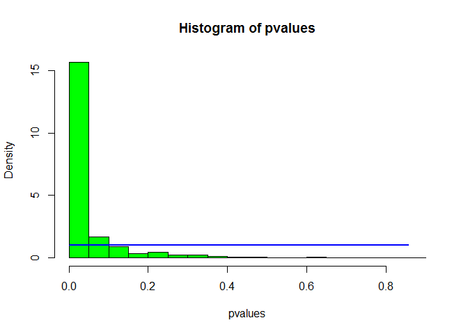

2) Критерий хи-квадрат проверки простой гипотезы согласия. Аналогично предыдущему пункту выбираете 3 распределения: дискретное, абсолютно непрерывное с ограниченным носителем, абсолютно непрерывное с неограниченным носителем, причем последние 2 берете такими же, что и для предыдущего задания; выбираете параметры θ_0; генерируете выборки из них объема 1000. Также как и выше, необходимо хотя бы раз реализовать вычисление статистики хи-квадрат вручную (по таблице наблюдаемые – ожидаемые). Проделать то же самое, что и выше (пункты 1-3) для критерия хи-квадрат. Сравнить результаты, полученные для критерия Колмогорова и хи-квадрат, между собой (как частные, так и распределение pvalue) дать комментарий и объяснения. Следует пояснить, что для правильного сравнения необходимо применять эти критерии к одним и тем же выборкам. Поэтому имеет смысл решать задания 1 и 2 одновременно.

[figure not shown]

[output not shown]

ДЛЯ БЕТА

1. Проверить простую гипотезу θ=θ_0 критерием Колмогорова на уровнях значимости α=0.01, 0.05, 0.1, 0.2. Необходимо реализовать вычисление статистики Колмогорова как вручную, так и вычислить pvalue с помощью стандартной функции. В остальных заданиях необязательно вычислять эту статистику вручную, но хотя бы 1 раз вы должны это проделать.

Пороговое значение критерия(квантили): (sqrt(-1/2*log(alpha/2))/sqrt(n))

```
## Empirical CDF
## Call: ecdf(beta)
##  x[1:1000] = 0.008, 0.01, 0.01,  ..., 0.9,  1
```

Статистика максимального отклонения d1<-abs(Fn(y) - F(y)) d2<-abs(Fn(y-eps) - F(y)) d<-max(d1,d2) и максимум считаем для всех в распред.

```
## [1] 0.0258
```

Квантили Колмогорова

```
## [1] 0.0339 0.0387 0.0429 0.0515
```

Какую гип примем на основе квантилей колм. < макс откл

```
## [1] "H_0"
## [1] "H_0"
## [1] "H_0"
## [1] "H_0"
```

Хи квадрат q_chisq:

[output not shown]

ПРОМЕЖУТКИ

```
## [1] 0.143 0.212 0.272 0.329 0.386 0.445 0.508 0.582 0.680
```

Смотрим: (наблюдаемые -ожид.)^2 / ожид. знач. попадания в промежутки

[output not shown]

Статист. и рез

```
## [1] 9.44
```

```
## [1] "H_0"
## [1] "H_0"
## [1] "H_0"
## [1] "H_0"
```

3. Проделать пункты 1 и 2 1000 раз (вычислять только pvalue). Построить гистограммы получившихся pvalue, на их основании ответить на вопрос о равномерности их распределения. Если ответ неочевиден, проверить гипотезу о равномерности на уровне значимости α=0.05 (можно тем же критерием Колмогорова) Прокомментировать полученные результаты.

p знач гист

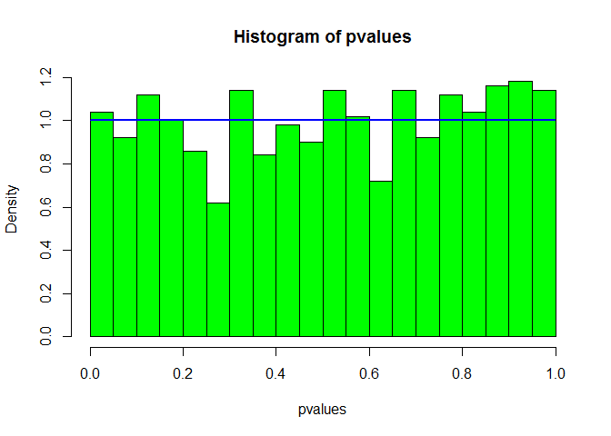

3) Сравнить результаты, полученные для критерия Колмогорова и хи-квадрат, между собой (как частные, так и распределение pvalue) дать комментарий и объяснения. Следует пояснить, что для правильного сравнения необходимо применять эти критерии к одним и тем же выборкам. Поэтому имеет смысл решать задания 1 и 2 одновременно.

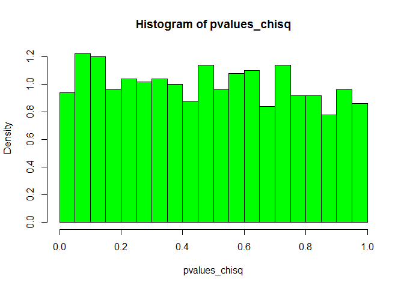

[output not shown]

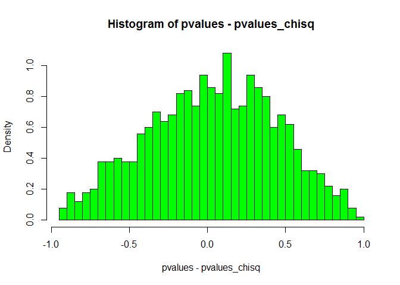

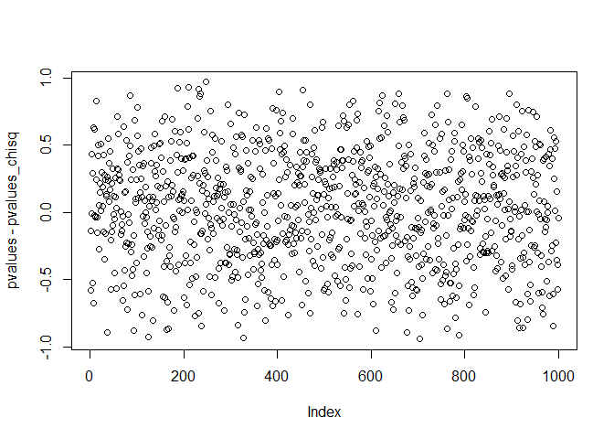